# 471 Midterm

Zhoumengdi Wang (zxw534)

```r
library(class)
library(rms)
```

## Load the data

```r
census_train = read.csv("census_train.csv")
census_train$income <- as.character((census_train$income))
income50 = rep(1, nrow(census_train))
income50[census_train$income == " <=50K"] = 0
census_train = data.frame (census_train , income50)
census_train$income <- factor(census_train$income, ordered = TRUE)
```

## 1.Preprocessing data/Perform exploratory analyses

### (1) What is missing data?

The first thing we need to do is preprocessing the data. Now we need to take care of the missing data. Hmisc::describe(census_train),this function can help us find the missing data. I use Hmisc::describe to view the whole data.

```r
Hmisc::describe(census_train)
```

```
## census_train
##
##  16  Variables      25000  Observations
## ---------------------------------------------------------------------------
## age
##        n  missing distinct     Info     Mean      Gmd      .05      .10
##    25000        0       73        1     38.6    15.41       19       22
##      .25      .50      .75      .90      .95
##       28       37       48       58       63
##
## lowest : 17 18 19 20 21, highest: 85 86 87 88 90
## ---------------------------------------------------------------------------
## workclass
##        n  missing distinct
##    25000        0        9
##
## ? (1404, 0.056), Federal-gov (734, 0.029), Local-gov (1606, 0.064),
## Never-worked (7, 0.000), Private (17447, 0.698), Self-emp-inc (856,
## 0.034), Self-emp-not-inc (1943, 0.078), State-gov (993, 0.040),
## Without-pay (10, 0.000)
## ---------------------------------------------------------------------------
## fnlwgt
##        n  missing distinct     Info     Mean      Gmd      .05      .10
##    25000        0    17865        1   189625   112271    39054    65474
##      .25      .50      .75      .90      .95
##   117833   178302   236986   328705   379069
##
## lowest :   12285   13769   14878   18827   19214
## highest: 1161363 1184622 1226583 1366120 1484705
## ---------------------------------------------------------------------------
## education
##        n  missing distinct
##    25000        0       16
##
## 10th (726, 0.029), 11th (897, 0.036), 12th (355, 0.014), 1st-4th (129,
## 0.005), 5th-6th (255, 0.010), 7th-8th (498, 0.020), 9th (402, 0.016),
## Assoc-acdm (822, 0.033), Assoc-voc (1062, 0.042), Bachelors (4105, 0.164),
## Doctorate (311, 0.012), HS-grad (8064, 0.323), Masters (1304, 0.052),
## Preschool (35, 0.001), Prof-school (450, 0.018), Some-college (5585,
## 0.223)
```

[output cut: 95 more lines]

```
## highest:  Thailand         Trinadad&Tobago  United-States    Vietnam          Yugoslavia
## ---------------------------------------------------------------------------
## income
##        n  missing distinct
##    25000        0        2
##
## Value      <=50K  >50K
## Frequency  19002  5998
## Proportion  0.76  0.24
## ---------------------------------------------------------------------------
## income50
##        n  missing distinct     Info      Sum     Mean      Gmd
##    25000        0        2    0.547     5998   0.2399   0.3647
##
## ---------------------------------------------------------------------------
```

See, there are three variables (workclass,occupation and native.country),which has the value”?”. “?” isn’t regarded as missing data, however, in fact, it is the missing data.

Use Na to replace the “?”

```r
census_train[census_train == " ?"] <- NA
```

```r
Hmisc::describe(census_train)
```

```
## census_train
##
##  16  Variables      25000  Observations
## ---------------------------------------------------------------------------
## age
##        n  missing distinct     Info     Mean      Gmd      .05      .10
##    25000        0       73        1     38.6    15.41       19       22
##      .25      .50      .75      .90      .95
##       28       37       48       58       63
##
## lowest : 17 18 19 20 21, highest: 85 86 87 88 90
## ---------------------------------------------------------------------------
## workclass
##        n  missing distinct
##    23596     1404        8
##
## Federal-gov (734, 0.031), Local-gov (1606, 0.068), Never-worked (7,
## 0.000), Private (17447, 0.739), Self-emp-inc (856, 0.036),
## Self-emp-not-inc (1943, 0.082), State-gov (993, 0.042), Without-pay (10,
## 0.000)
## ---------------------------------------------------------------------------
## fnlwgt
##        n  missing distinct     Info     Mean      Gmd      .05      .10
##    25000        0    17865        1   189625   112271    39054    65474
##      .25      .50      .75      .90      .95
##   117833   178302   236986   328705   379069
##
## lowest :   12285   13769   14878   18827   19214
## highest: 1161363 1184622 1226583 1366120 1484705
## ---------------------------------------------------------------------------
## education
##        n  missing distinct
##    25000        0       16
##
## 10th (726, 0.029), 11th (897, 0.036), 12th (355, 0.014), 1st-4th (129,
## 0.005), 5th-6th (255, 0.010), 7th-8th (498, 0.020), 9th (402, 0.016),
## Assoc-acdm (822, 0.033), Assoc-voc (1062, 0.042), Bachelors (4105, 0.164),
## Doctorate (311, 0.012), HS-grad (8064, 0.323), Masters (1304, 0.052),
## Preschool (35, 0.001), Prof-school (450, 0.018), Some-college (5585,
## 0.223)
```

[output cut: 95 more lines]

```
## highest:  Thailand         Trinadad&Tobago  United-States    Vietnam          Yugoslavia
## ---------------------------------------------------------------------------
## income
##        n  missing distinct
##    25000        0        2
##
## Value      <=50K  >50K
## Frequency  19002  5998
## Proportion  0.76  0.24
## ---------------------------------------------------------------------------
## income50
##        n  missing distinct     Info      Sum     Mean      Gmd
##    25000        0        2    0.547     5998   0.2399   0.3647
##
## ---------------------------------------------------------------------------
```

### (2)How to deal with the missing data

With the missing data, there are some ways to deal with: 1. delete 2. use the highest frequency value to replace the missing data 3. use the relationships between variables I will combine 2 and 3 to deal with the missing data.

We need to create the dataset with removing the missing data and the dataset with missing data.

```r
census_train_completed = na.omit(census_train)
nrow(census_train) - nrow(census_train_completed)
```

```
## [1] 1829
```

```r
list <-which(rowSums(is.na(census_train)) > 0)
census_train_missing <-  census_train[list,]
```

The first class which has the missing data is workclass. I think the workclass is influenced by occupation. So my first step is dealing with the missing data in occupation. For the missing data in occupation, I would like to use highest frequency value to replace the missing data.

```r
FindMode <- function(x) {

    ux <- unique(x)

    ux[which.max(tabulate(match(x, ux)))]

}
FindMode(census_train_completed$occupation)
```

```
## [1]  Prof-specialty
## 15 Levels:  ?  Adm-clerical  Armed-Forces ...  Transport-moving
```

So the highest frequency value of occupation is Prof-specialty. I use Prof-specialty to replace the NA in occupation.

```r
census_train_missing$occupation <- as.character((census_train_missing$occupation))
census_train_missing$occupation[is.na(census_train_missing$occupation)] <- "Prof-specialty"
```

After dealing with the missing data in occupation, I need to find the relationship between the occupation and workclass. Show the table of these two vatiables:

```r
occupation_workclass = table(census_train_completed$occupation,census_train_completed$workclass)
write.csv(occupation_workclass,file="occupation_workclass.csv")
```

We can find that when the occupation is Prof-specialty, the highest frequency value of workclass is private. I use private to replace the missing data in workclass.

```r
census_train_missing$workclass <- as.character((census_train_missing$workclass))
census_train_missing$workclass[is.na(census_train_missing$workclass)] <- " Private"
```

For the missing data in native.country, I also use the highest frequency value.

```r
FindMode <- function(x) {

    ux <- unique(x)

    ux[which.max(tabulate(match(x, ux)))]

}
FindMode(census_train_completed$native.country)
```

```
## [1]  United-States
## 42 Levels:  ?  Cambodia  Canada  China  Columbia ...  Yugoslavia
```

So the highest frequency value of native.country is United-States. I use United-States to replace the missing data.

```r
census_train_missing$native.country <- as.character((census_train_missing$native.country))
census_train_missing$native.country[is.na(census_train_missing$native.country)] <- " United-States"
```

After dealing with the missing data, let’s review the dataset with missing data again.

```r
Hmisc::describe(census_train_missing)
```

```
## census_train_missing
##
##  16  Variables      1829  Observations
## ---------------------------------------------------------------------------
## age
##        n  missing distinct     Info     Mean      Gmd      .05      .10
##     1829        0       70    0.999    40.26    21.31       18       19
##      .25      .50      .75      .90      .95
##       22       35       58       67       72
##
## lowest : 17 18 19 20 21, highest: 82 83 84 87 90
## ---------------------------------------------------------------------------
## workclass
##        n  missing distinct
##     1829        0        7
##
## Federal-gov (11, 0.006), Local-gov (24, 0.013), Never-worked (7, 0.004),
## Private (1715, 0.938), Self-emp-inc (29, 0.016), Self-emp-not-inc (27,
## 0.015), State-gov (16, 0.009)
## ---------------------------------------------------------------------------
## fnlwgt
##        n  missing distinct     Info     Mean      Gmd      .05      .10
##     1829        0     1753        1   188017   108512    37865    65514
##      .25      .50      .75      .90      .95
##   122244   177487   232512   321448   376046
##
## lowest :  12285  20469  22966  23233  23780, highest: 591711 634226 640383 659273 860348
## ---------------------------------------------------------------------------
## education
##        n  missing distinct
##     1829        0       16
##
## 10th (90, 0.049), 11th (95, 0.052), 12th (41, 0.022), 1st-4th (15, 0.008),
## 5th-6th (30, 0.016), 7th-8th (64, 0.035), 9th (47, 0.026), Assoc-acdm (50,
## 0.027), Assoc-voc (64, 0.035), Bachelors (236, 0.129), Doctorate (29,
## 0.016), HS-grad (509, 0.278), Masters (73, 0.040), Preschool (1, 0.001),
## Prof-school (25, 0.014), Some-college (460, 0.252)
## ---------------------------------------------------------------------------
## education.num
##        n  missing distinct     Info     Mean      Gmd      .05      .10
```

[output cut: 92 more lines]

```
## highest:  Taiwan           Thailand         Trinadad&Tobago  United-States    Vietnam
## ---------------------------------------------------------------------------
## income
##        n  missing distinct
##     1829        0        2
##
## Value      <=50K  >50K
## Frequency   1571   258
## Proportion 0.859 0.141
## ---------------------------------------------------------------------------
## income50
##        n  missing distinct     Info      Sum     Mean      Gmd
##     1829        0        2    0.363      258   0.1411   0.2425
##
## ---------------------------------------------------------------------------
```

There is no more missing data, so let’s gruop missing data and completed dataset.

```r
census_train_new = rbind(census_train_completed,census_train_missing)
```

### (3) Check the variables

#### Close definition variables

I found there are two pairs variables: education and education.num, marital_status and relationship, which have close definition. Get the table of education and education.num:

```r
education.num_education = table(census_train_new$education.num, census_train_new$education)
write.csv(education.num_education,file="education.num_education.csv")
```

The table shows that each class of education.num matches a education level, so I think the education should be dropped.

Get the table of marital.status and relationship:

```r
marital_status_relationship = table(census_train_new$marital.status, census_train_new$relationship)
write.csv(marital_status_relationship,file="marital.status_relationship.csv")
```

I think marital.status is more clear than the relationship, so I decide to drop relationship. And I will combine Married-AF-spouse and Married-civ-spouse into a single category called Married.

```r
levels(census_train_new$marital.status)
```

```
## [1] " Divorced"              " Married-AF-spouse"
## [3] " Married-civ-spouse"    " Married-spouse-absent"
## [5] " Never-married"         " Separated"
## [7] " Widowed"
```

```r
levels(census_train_new$marital.status)[2] <- " Married"
levels(census_train_new$marital.status)[3] <- " Married"
levels(census_train_new$marital.status)
```

```
## [1] " Divorced"              " Married"
## [3] " Married-spouse-absent" " Never-married"
## [5] " Separated"             " Widowed"
```

#### Watch quantitative data

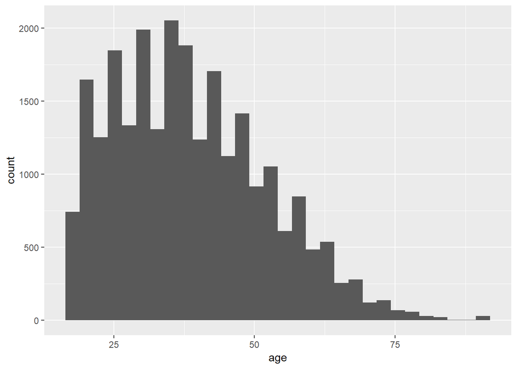

```r
ggplot(data=census_train_new, aes(x=age)) + geom_histogram()
```

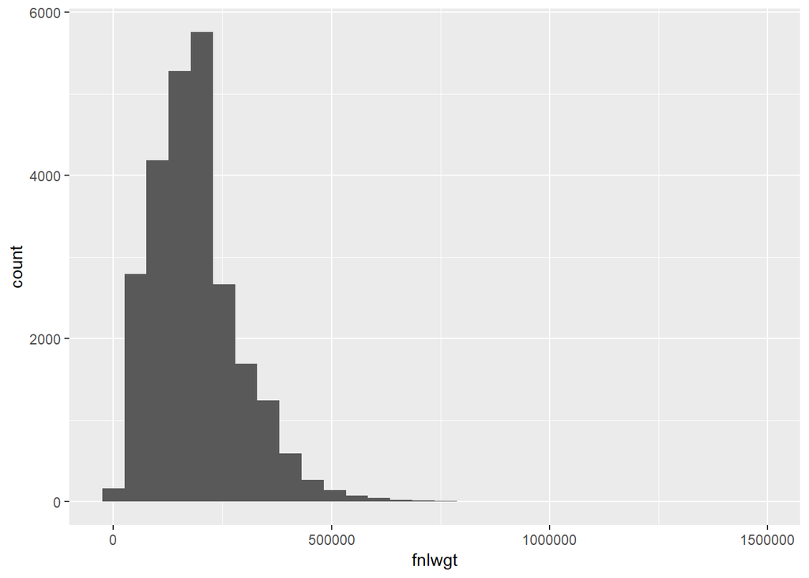

```r
ggplot(data=census_train_new, aes(x=fnlwgt)) + geom_histogram()
```

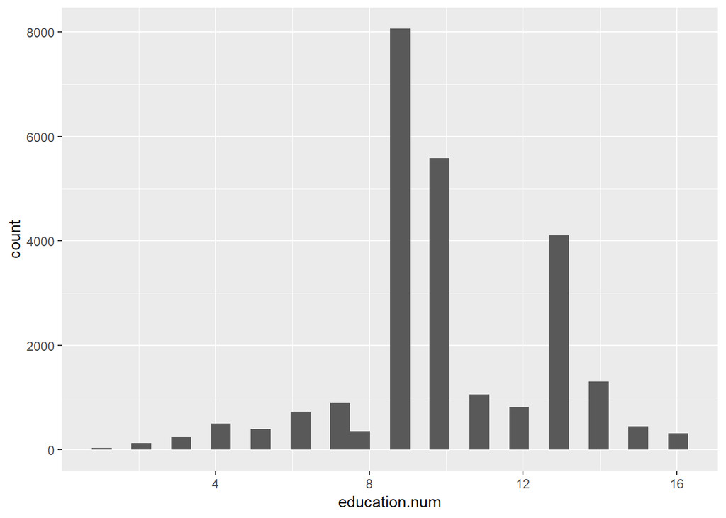

```r
ggplot(data=census_train_new, aes(x=education.num)) + geom_histogram()
```

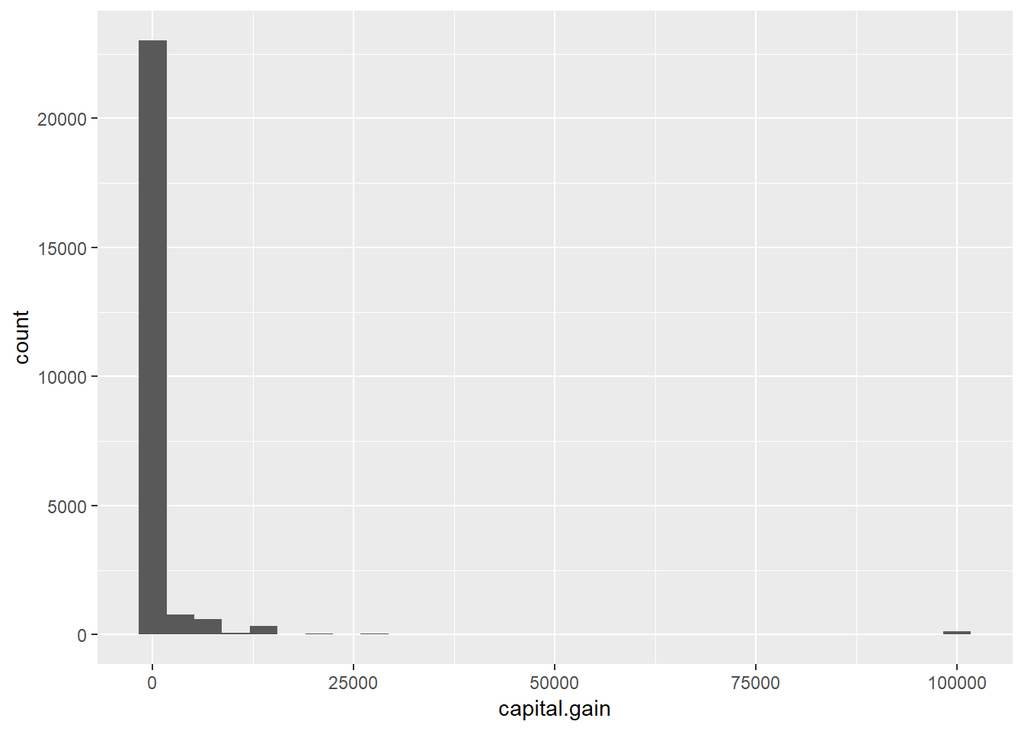

```r
ggplot(data=census_train_new, aes(x=capital.gain)) + geom_histogram()
```

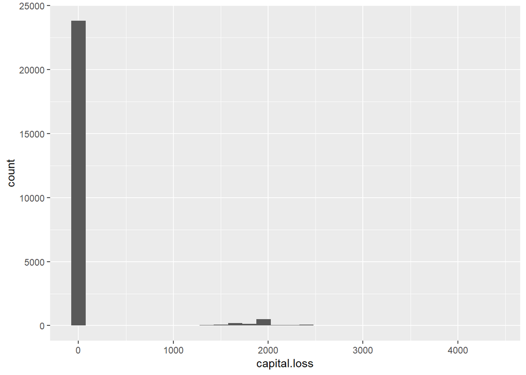

```r
ggplot(data=census_train_new, aes(x=capital.loss)) + geom_histogram()
```

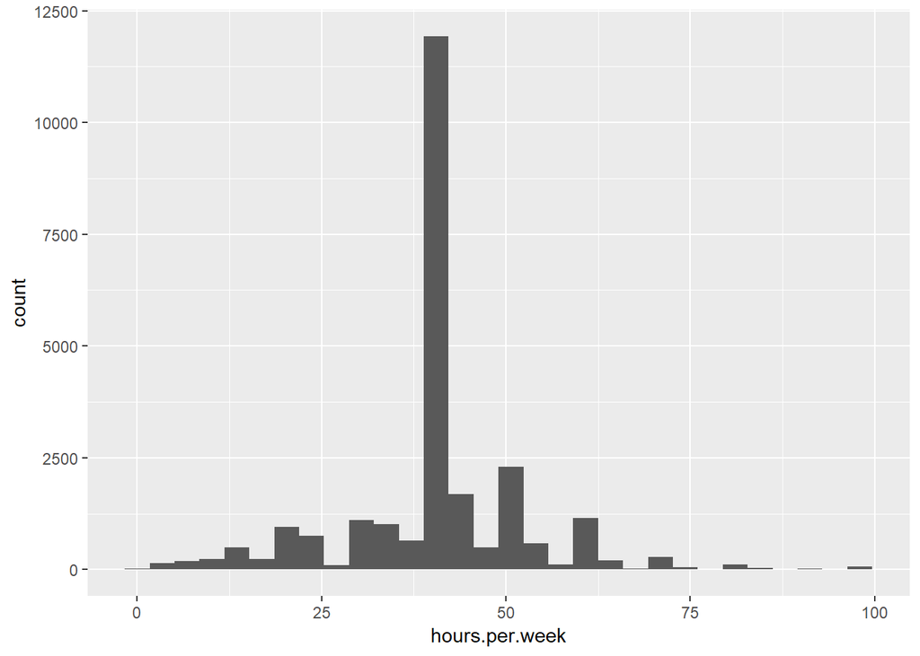

```r
ggplot(data=census_train_new, aes(x=hours.per.week)) + geom_histogram()
```

According to the histograms, capital.gain and capital.loss of most people is zero. In fact, these two variables relate to privacy, I may delete them in adjusting models.

#### Watch qualitative data

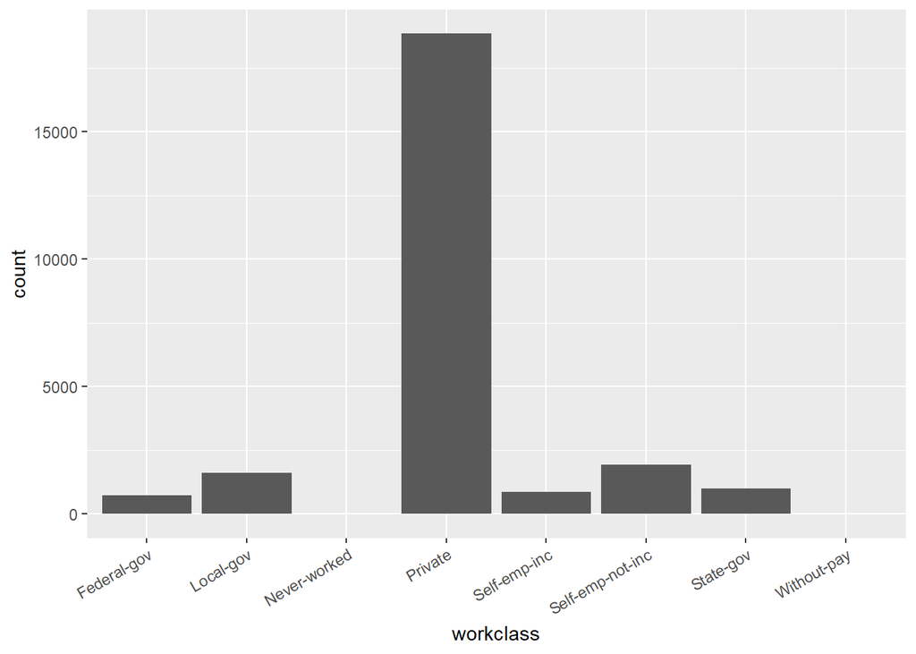

```r
ggplot(data=census_train_new, aes(x=workclass)) + geom_bar() +theme(axis.text.x = element_text(angle = 30, hjust = 1))
```

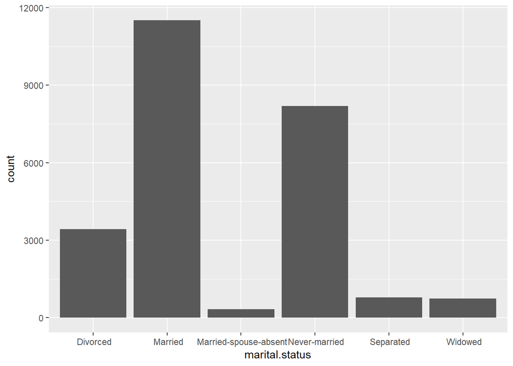

```r
ggplot(data=census_train_new, aes(x=marital.status)) + geom_bar()
```

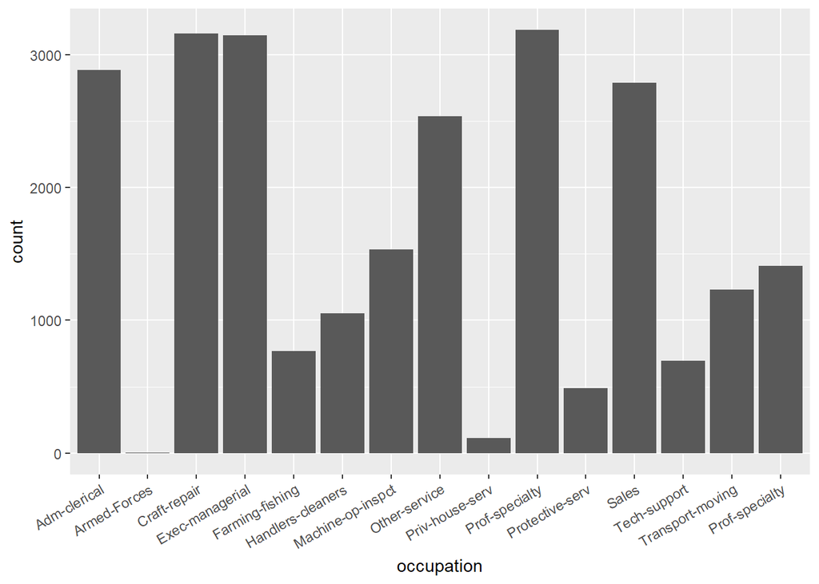

```r
ggplot(data=census_train_new, aes(x=occupation)) + geom_bar() + theme(axis.text.x = element_text(angle = 30, hjust = 1))
```

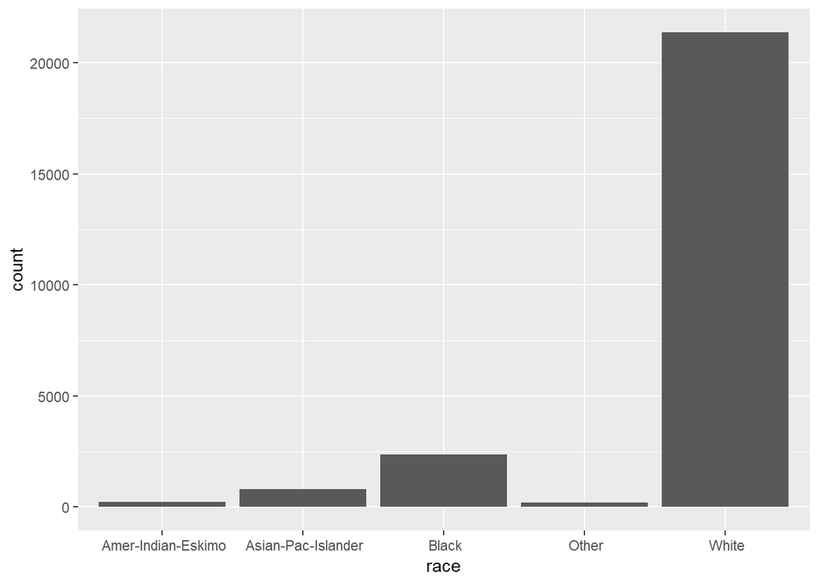

```r
ggplot(data=census_train_new, aes(x=race)) + geom_bar()
```

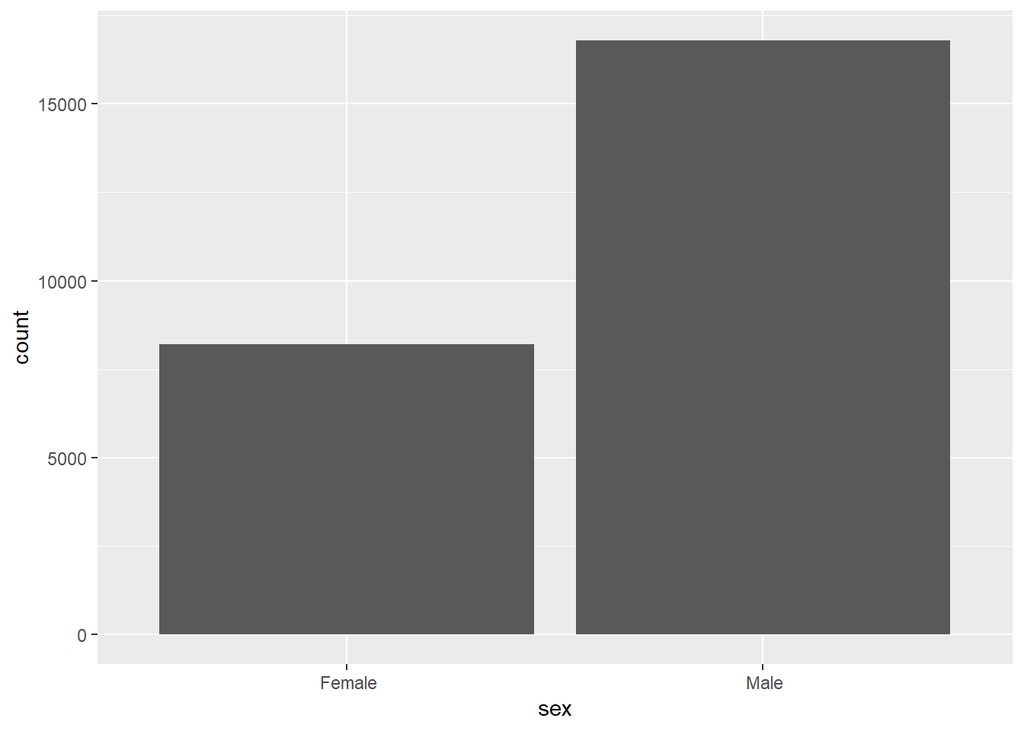

```r
ggplot(data=census_train_new, aes(x=sex)) + geom_bar()
```

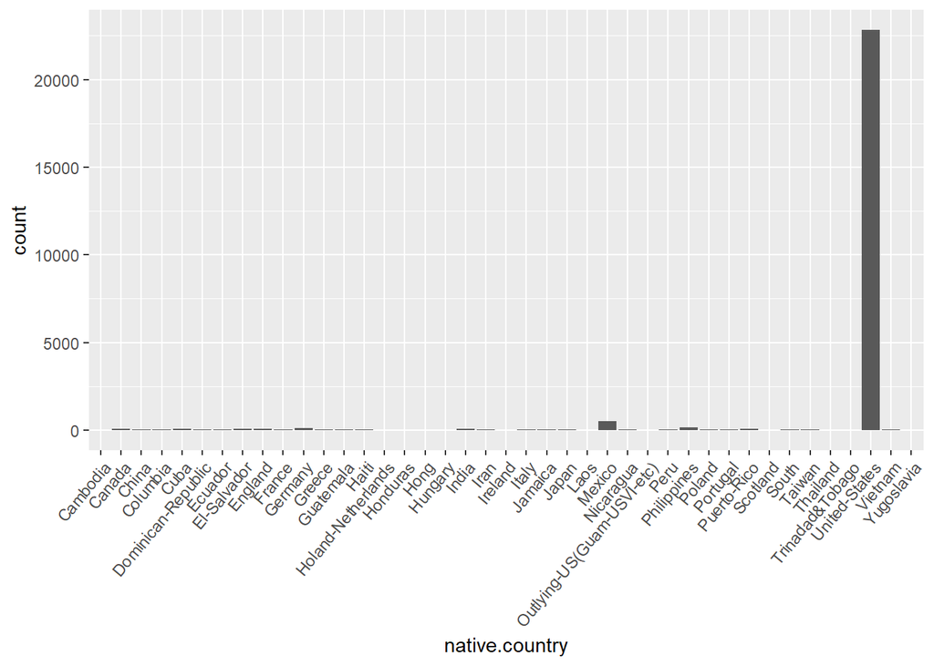

```r
ggplot(data=census_train_new, aes(x=native.country)) + geom_bar() + theme(axis.text.x = element_text(angle = 50, hjust = 1))
```

For native.country, almost all people’s native.country is United-Staste. So I will combine other countries into a new label“other country”

```r
levels(census_train_new$native.country)
```

```
##  [1] " ?"                          " Cambodia"
##  [3] " Canada"                     " China"
##  [5] " Columbia"                   " Cuba"
##  [7] " Dominican-Republic"         " Ecuador"
##  [9] " El-Salvador"                " England"
## [11] " France"                     " Germany"
## [13] " Greece"                     " Guatemala"
## [15] " Haiti"                      " Holand-Netherlands"
## [17] " Honduras"                   " Hong"
## [19] " Hungary"                    " India"
## [21] " Iran"                       " Ireland"
## [23] " Italy"                      " Jamaica"
## [25] " Japan"                      " Laos"
## [27] " Mexico"                     " Nicaragua"
## [29] " Outlying-US(Guam-USVI-etc)" " Peru"
## [31] " Philippines"                " Poland"
## [33] " Portugal"                   " Puerto-Rico"
## [35] " Scotland"                   " South"
## [37] " Taiwan"                     " Thailand"
## [39] " Trinadad&Tobago"            " United-States"
## [41] " Vietnam"                    " Yugoslavia"
```

```r
levels(census_train_new$native.country)[1:39] <- " Other Country"
levels(census_train_new$native.country)[3:4] <- " Other Country"
levels(census_train_new$native.country)
```

```
## [1] " Other Country" " United-States"
```

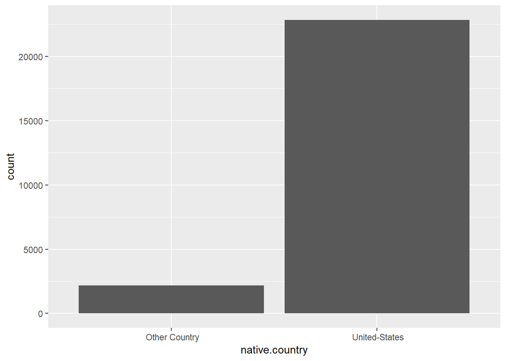

```r
ggplot(data=census_train_new, aes(x=native.country)) + geom_bar()
```

#### Check collinearity

```r
census_train_new <-  census_train_new[,c(1,2,3,5,6,7,9,10,11,12,13,14,15,16)]
```

```r
census_train_new_quantitative <-(census_train_new[,c(1,3,4,9,10,11)])
census_train_new_qualitative <- (census_train_new[,c(2,5,6,7,8,12)])
```

```r
cor(census_train_new_quantitative)
```

```
##                        age        fnlwgt education.num  capital.gain
## age             1.00000000 -0.0754229958    0.03745462  0.0803364007
## fnlwgt         -0.07542300  1.0000000000   -0.04596356 -0.0004977309
## education.num   0.03745462 -0.0459635576    1.00000000  0.1299508553
## capital.gain    0.08033640 -0.0004977309    0.12995086  1.0000000000
## capital.loss    0.06110263 -0.0109322145    0.08314796 -0.0318820464
## hours.per.week  0.06864841 -0.0153756410    0.15357666  0.0850860033
##                capital.loss hours.per.week
## age              0.06110263     0.06864841
## fnlwgt          -0.01093221    -0.01537564
## education.num    0.08314796     0.15357666
## capital.gain    -0.03188205     0.08508600
## capital.loss     1.00000000     0.05688347
## hours.per.week   0.05688347     1.00000000
```

Most variables do not have strong collinearity, but the collinearity values of education.num-capital.gain and education.num-hours.per.week is higher than 0.1. According to ISLR, I can delete some variables which have collinearity.Howerver,I don’t want to delete too many variables.

#### check variables and income

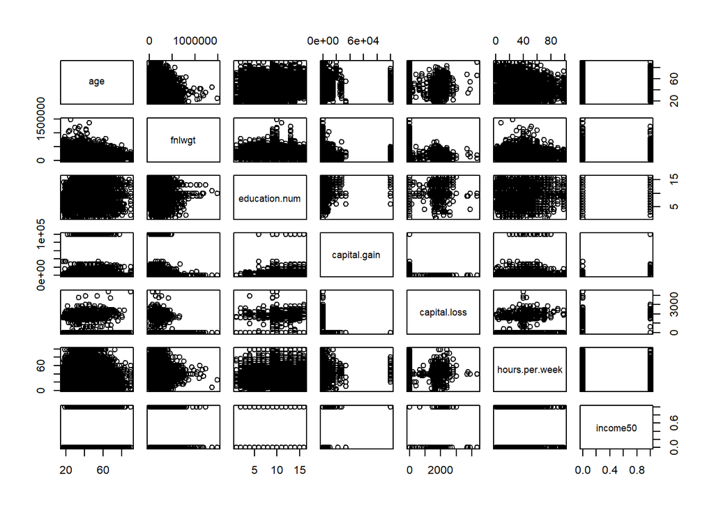

```r
census_train_new_quantitative_income <-(census_train_new[,c(1,3,4,9,10,11,14)])
pairs(census_train_new_quantitative_income)
```

No quantitative variable is the determinative role of income.

```r
census_train_new$occupation <- factor(census_train_new$occupation, ordered = TRUE)
census_train_new$workclass <- factor(census_train_new$workclass, ordered = TRUE)
census_train_new$native.country <- factor(census_train_new$native.country, ordered = TRUE)
census_train_new$marital.status <- factor(census_train_new$marital.status, ordered = TRUE)
```

```r
table(census_train_new$workclass, census_train_new$income)
```

```
##
##                      <=50K  >50K
##    Federal-gov         447   287
##    Local-gov          1141   465
##    Never-worked          7     0
##    Private           14888  3963
##    Self-emp-inc        381   475
##    Self-emp-not-inc   1396   547
##    State-gov           732   261
##    Without-pay          10     0
```

```r
table(census_train_new$marital.status, census_train_new$income)
```

```
##
##                           <=50K  >50K
##    Divorced                3070   355
##    Married                 6361  5150
##    Married-spouse-absent    302    25
##    Never-married           7844   352
##    Separated                735    55
##    Widowed                  690    61
```

```r
table(census_train_new$occupation, census_train_new$income)
```

```
##
##                       <=50K  >50K
##    Adm-clerical        2503   382
##    Armed-Forces           5     1
##    Craft-repair        2441   719
##    Exec-managerial     1628  1518
##    Farming-fishing      676    94
##    Handlers-cleaners    981    70
##    Machine-op-inspct   1354   180
##    Other-service       2435   101
##    Priv-house-serv      113     1
##    Prof-specialty      1771  1415
##    Protective-serv      330   157
##    Sales               2043   743
##    Tech-support         486   211
##    Transport-moving     977   254
##   Prof-specialty       1259   152
```

```r
table(census_train_new$race, census_train_new$income)
```

```
##
##                        <=50K  >50K
##    Amer-Indian-Eskimo    214    25
##    Asian-Pac-Islander    592   214
##    Black                2077   292
##    Other                 197    19
##    White               15922  5448
```

```r
table(census_train_new$sex, census_train_new$income)
```

```
##
##            <=50K  >50K
##    Female   7310   903
##    Male    11692  5095
```

```r
table(census_train_new$native.country, census_train_new$income)
```

```
##
##                   <=50K  >50K
##    Other Country   1773   396
##    United-States  17229  5602
```

No qualitative variable has the determinative role of income.

## 2.Creating models

In this part, I will use 10 fold cross-validation to find a better model.

```r
set.seed(6)
require(caret)
folds <- createFolds(y=census_train_new$income50,k=10)
```

### (1) Logistic Regression / LDA / KNN

```r
min=100
num=0
for(i in 1:10){

  fold_test <- census_train_new[folds[[i]],]
  fold_train <- census_train_new[-folds[[i]],]

  log.reg = glm((income50 == 1) ~
                 # Quantitative
                 age + fnlwgt  + hours.per.week + education.num + capital.gain +
                  capital.loss+

                 # Qualitative
                 sex + race + marital.status + native.country + workclass + occupation,
                data=fold_train,family=binomial)

  fold_predict <- predict(log.reg,type='response',newdata=fold_test)
  fold_predict = ifelse(fold_predict>0.5,1,0)
  fold_accuracy = mean(fold_predict != fold_test$income50)


  if(fold_accuracy<min)
    {
    min=fold_accuracy
    num=i
    }

}
print(min)
```

```
## [1] 0.1392
```

```r
print(num)
```

```
## [1] 10
```

```r
summary(log.reg)
```

```
##
## Call:
## glm(formula = (income50 == 1) ~ age + fnlwgt + hours.per.week +
##     education.num + capital.gain + capital.loss + sex + race +
##     marital.status + native.country + workclass + occupation,
##     family = binomial, data = fold_train)
##
## Deviance Residuals:
##     Min       1Q   Median       3Q      Max
## -4.2844  -0.5017  -0.2037  -0.0467   3.7888
##
## Coefficients:
##                           Estimate Std. Error z value Pr(>|z|)
## (Intercept)             -1.191e+01  3.375e+01  -0.353 0.724075
## age                      2.723e-02  1.922e-03  14.168  < 2e-16 ***
## fnlwgt                   7.123e-07  2.061e-07   3.456 0.000548 ***
## hours.per.week           3.098e-02  1.940e-03  15.964  < 2e-16 ***
## education.num            2.836e-01  1.098e-02  25.829  < 2e-16 ***
## capital.gain             3.267e-04  1.247e-05  26.209  < 2e-16 ***
## capital.loss             6.677e-04  4.470e-05  14.936  < 2e-16 ***
## sex Male                 1.277e-01  6.268e-02   2.037 0.041643 *
## race Asian-Pac-Islander  5.519e-01  2.910e-01   1.896 0.057921 .
## race Black               3.947e-01  2.743e-01   1.439 0.150197
## race Other              -8.768e-02  4.133e-01  -0.212 0.831999
## race White               5.318e-01  2.611e-01   2.037 0.041677 *
## marital.status.L        -1.005e+00  1.336e-01  -7.522 5.39e-14 ***
## marital.status.Q        -6.685e-02  1.616e-01  -0.414 0.679046
## marital.status.C         1.310e+00  1.434e-01   9.135  < 2e-16 ***
## marital.status^4        -1.355e+00  1.503e-01  -9.017  < 2e-16 ***
## marital.status^5         3.646e-01  1.842e-01   1.979 0.047761 *
## native.country.L         1.679e-01  6.461e-02   2.598 0.009364 **
## workclass.L             -4.632e+00  9.517e+01  -0.049 0.961182
## workclass.Q             -4.013e+00  9.517e+01  -0.042 0.966365
## workclass.C             -9.389e+00  1.163e+02  -0.081 0.935660
## workclass^4             -1.646e+00  4.970e+01  -0.033 0.973581
## workclass^5              1.545e+00  8.524e+01   0.018 0.985542
## workclass^6             -6.181e+00  1.257e+02  -0.049 0.960786
## workclass^7              2.971e+00  8.118e+01   0.037 0.970807
## occupation.L            -1.883e-02  8.730e-01  -0.022 0.982791
## occupation.Q             1.135e+00  8.894e-01   1.277 0.201700
## occupation.C            -5.120e-01  3.511e-01  -1.458 0.144799
## occupation^4            -1.926e+00  6.775e-01  -2.843 0.004468 **
## occupation^5            -3.123e-01  9.617e-01  -0.325 0.745354
## occupation^6             1.103e+00  1.133e+00   0.973 0.330316
## occupation^7             5.391e-01  1.184e+00   0.455 0.648904
## occupation^8            -2.351e-01  8.695e-01  -0.270 0.786900
## occupation^9            -1.106e+00  9.223e-01  -1.199 0.230461
## occupation^10            1.764e-01  3.518e-01   0.501 0.616052
## occupation^11            2.231e+00  8.143e-01   2.740 0.006152 **
## occupation^12           -7.552e-02  3.619e-01  -0.209 0.834718
## occupation^13           -1.045e+00  7.795e-01  -1.340 0.180190
## occupation^14           -1.499e+00  1.045e+00  -1.435 0.151382
## ---
## Signif. codes:  0 '***' 0.001 '**' 0.01 '*' 0.05 '.' 0.1 ' ' 1
##
## (Dispersion parameter for binomial family taken to be 1)
##
##     Null deviance: 24778  on 22499  degrees of freedom
## Residual deviance: 14407  on 22461  degrees of freedom
## AIC: 14485
##
## Number of Fisher Scoring iterations: 12
```

#### LDA

```r
library(MASS)
min=100
num=0
for(i in 1:10){
  fold_test <- census_train_new[folds[[i]],]
  fold_train <- census_train_new[-folds[[i]],]
  lda1 = lda((income50 == 1) ~ age + workclass + fnlwgt + education.num +
                    marital.status + occupation + race + sex + capital.gain +
                    capital.loss + hours.per.week + native.country,

            data=fold_train)

  fold_predict <- predict(lda1,type='response',newdata=fold_test)
  fold_predict = ifelse(fold_predict$class == "TRUE", 1,0)
  fold_accuracy = mean(fold_predict != fold_test$income50)


  if(fold_accuracy<min)
    {
    min=fold_accuracy
    num=i
    }
}

print(min)
```

```
## [1] 0.1512
```

```r
print(num)
```

```
## [1] 4
```

#### KNN k=1,3,5,10,50,100

```r
Knn_cv <- function(n,data) {

    min=100
    num=0
for(i in 1:10){
  fold_test <- data[folds[[i]],]
  fold_train <- data[-folds[[i]],]

  train.X = cbind(fold_train$age, fold_train$fnlwgt,
                fold_train$capital.gain, fold_train$capital.loss,
                fold_train$hours.per.week,fold_train$native.country,
                fold_train$workclass,fold_train$education.num,
                fold_train$marital.status,fold_train$occupation,
                fold_train$race,fold_train$sex)

  query.X = cbind(fold_test$age,fold_test$fnlwgt,
                fold_test$capital.gain, fold_test$capital.loss,
                fold_test$hours.per.week,fold_test$native.country,
                fold_test$workclass,fold_test$education.num,
                fold_test$marital.status,fold_test$occupation,
                fold_test$race,fold_test$sex)

  set.seed(1)
  knn1 = knn(train.X, query.X, fold_train$income50, k = n)

  fold_accuracy = mean(knn1 != fold_test$income50)


  if(fold_accuracy<min)
    {
    min=fold_accuracy
    num=i
    }
}

print(min)
print(num)

}
```

```r
print("K = 1")
```

```
## [1] "K = 1"
```

```r
Knn_cv(1,census_train_new)
```

```
## [1] 0.2524
## [1] 9
```

```r
print("K = 3")
```

```
## [1] "K = 3"
```

```r
Knn_cv(3,census_train_new)
```

```
## [1] 0.2252
## [1] 9
```

```r
print("K = 5")
```

```
## [1] "K = 5"
```

```r
Knn_cv(5,census_train_new)
```

```
## [1] 0.2084
## [1] 9
```

```r
print("K = 10")
```

```
## [1] "K = 10"
```

```r
Knn_cv(10,census_train_new)
```

```
## [1] 0.2004
## [1] 9
```

```r
print("K = 50")
```

```
## [1] "K = 50"
```

```r
Knn_cv(50,census_train_new)
```

```
## [1] 0.1956
## [1] 9
```

```r
print("K = 100")
```

```
## [1] "K = 100"
```

```r
Knn_cv(100,census_train_new)
```

```
## [1] 0.2032
## [1] 9
```

The LDA and KNN performance worse than logistic. We decided to go with the logistic regression and fine-tune it.

### (2) Adjusting Logistic Regression

#### delete capital.loss and capital.gain

```r
min=100
num=0
for(i in 1:10){
  fold_test <- census_train_new[folds[[i]],]
  fold_train <- census_train_new[-folds[[i]],]

  log.reg1 = glm((income50 == 1) ~
                 # Quantitative
                 age + fnlwgt  + hours.per.week + education.num +

                 # Qualitative
                 sex + race + marital.status + native.country + workclass +
                   occupation, data=fold_train,family=binomial)

  log.reg.probabilities1 = predict(log.reg1, fold_test, type="response")
  log.reg.predictions1 = ifelse(log.reg.probabilities1 > 0.5, 1, 0)
  fold_accuracy = mean(log.reg.predictions1 != fold_test$income50)


  if(fold_accuracy<min)
    {
    min=fold_accuracy
    num=i
    }
}

print(min)
```

```
## [1] 0.1524
```

```r
print(num)
```

```
## [1] 10
```

It performance worse before removing capital.loss and capital.gain, so I will keep them.

```r
min=100
num=0
for(i in 1:10){
  fold_test <- census_train_new[folds[[i]],]
  fold_train <- census_train_new[-folds[[i]],]

  log.reg2 = glm((income50 == 1) ~
                 # Quantitative
                 rcs(age, 5) + rcs(fnlwgt, 5) + rcs(capital.gain, 5) +
                 rcs(capital.loss, 5) + rcs(hours.per.week, 5) + rcs(education.num,5)
                 +
                 # Qualitative
                 sex + race + marital.status + native.country + workclass +
                   occupation,
                data=fold_train, family=binomial)

  log.reg.probabilities2 = predict(log.reg2, fold_test, type="response")
  log.reg.predictions2 = ifelse(log.reg.probabilities2 > 0.5, 1, 0)
  fold_accuracy = mean(log.reg.predictions2 != fold_test$income50)


  if(fold_accuracy<min)
    {
    min=fold_accuracy
    num=i
    }
}

print(min)
```

```
## [1] 0.156
```

```r
print(num)
```

```
## [1] 8
```

```r
summary(log.reg2)
```

```
##
## Call:
## glm(formula = (income50 == 1) ~ rcs(age, 5) + rcs(fnlwgt, 5) +
##     rcs(capital.gain, 5) + rcs(capital.loss, 5) + rcs(hours.per.week,
##     5) + rcs(education.num, 5) + sex + race + marital.status +
##     native.country + workclass + occupation, family = binomial,
##     data = fold_train)
##
## Deviance Residuals:
##     Min       1Q   Median       3Q      Max
## -4.5971  -0.4780  -0.1809  -0.0153   4.0337
##
## Coefficients:
##                                          Estimate Std. Error z value
## (Intercept)                            -1.883e+01  3.218e+01  -0.585
## rcs(age, 5)age                          3.106e-01  3.986e-02   7.794
## rcs(age, 5)age'                        -1.015e+00  1.988e-01  -5.104
## rcs(age, 5)age''                        2.441e+00  5.565e-01   4.386
## rcs(age, 5)age'''                      -1.824e+00  4.869e-01  -3.746
## rcs(fnlwgt, 5)fnlwgt                    3.218e-08  1.573e-06   0.020
## rcs(fnlwgt, 5)fnlwgt'                   1.464e-05  1.059e-05   1.383
## rcs(fnlwgt, 5)fnlwgt''                 -8.631e-05  4.556e-05  -1.894
## rcs(fnlwgt, 5)fnlwgt'''                 1.412e-04  6.220e-05   2.271
## rcs(capital.gain, 5)capital.gain       -1.288e-03  1.720e-04  -7.487
## rcs(capital.gain, 5)capital.gain'       1.378e+00  1.747e-01   7.890
## rcs(capital.gain, 5)capital.gain''     -2.506e+00  3.421e-01  -7.326
## rcs(capital.gain, 5)capital.gain'''     1.309e+00  2.130e-01   6.143
## rcs(capital.loss, 5)capital.loss       -1.524e-03  8.089e-04  -1.884
## rcs(capital.loss, 5)capital.loss'       4.149e-03  2.204e-03   1.882
## rcs(capital.loss, 5)capital.loss''     -1.397e-03  3.346e-02  -0.042
## rcs(capital.loss, 5)capital.loss'''    -2.903e-01  2.238e-01  -1.297
## rcs(hours.per.week, 5)hours.per.week    1.135e-02  6.946e-03   1.634
## rcs(hours.per.week, 5)hours.per.week'   7.183e-02  1.251e-02   5.742
## rcs(hours.per.week, 5)hours.per.week'' -9.956e-01  1.329e-01  -7.491
## rcs(education.num, 5)education.num      1.865e-01  4.449e-02   4.192
## rcs(education.num, 5)education.num'     2.702e-01  1.409e-01   1.918
## rcs(education.num, 5)education.num''   -4.641e+00  1.821e+00  -2.548
## rcs(education.num, 5)education.num'''   7.447e+00  2.568e+00   2.900
## sex Male                                6.879e-02  6.520e-02   1.055
## race Asian-Pac-Islander                 6.899e-01  3.025e-01   2.281
```

[output cut: 82 more lines]

```
## occupation^10                           0.63286
## occupation^11                           0.11835
## occupation^12                           0.76291
## occupation^13                           0.38403
## occupation^14                           0.35157
## ---
## Signif. codes:  0 '***' 0.001 '**' 0.01 '*' 0.05 '.' 0.1 ' ' 1
##
## (Dispersion parameter for binomial family taken to be 1)
##
##     Null deviance: 24778  on 22499  degrees of freedom
## Residual deviance: 13635  on 22444  degrees of freedom
## AIC: 13747
##
## Number of Fisher Scoring iterations: 12
```

#### reduce the number of nodes for fnlwgt and capital.loss from 5 to 3 and added several interaction terms

```r
min=100
num=0
for(i in 1:10){
  fold_test <- census_train_new[folds[[i]],]
  fold_train <- census_train_new[-folds[[i]],]

  log.reg3 = glm((income50 == 1) ~

                 # Quantitative
                 rcs(age, 5) + rcs(fnlwgt, 3) + rcs(capital.gain, 5) +
                 rcs(capital.loss, 3) + rcs(hours.per.week, 5) + rcs(education.num,5) +

                 # Qualitative
                 sex + race + marital.status + workclass + native.country
                  + occupation +

                 # Interactions
                 marital.status * age + workclass * age +
                 education.num * age + hours.per.week * workclass +
                 hours.per.week * occupation + age * hours.per.week,
                data=fold_train, family=binomial)

  log.reg.probabilities3 = predict(log.reg3, fold_test, type="response")
  log.reg.predictions3 = ifelse(log.reg.probabilities3 > 0.5, 1, 0)
  fold_accuracy = mean(log.reg.predictions3 != fold_test$income50)


  if(fold_accuracy<min)
    {
    min=fold_accuracy
    num=i
    }
}
print(min)
```

```
## [1] 0.1544
```

```r
print(num)
```

```
## [1] 8
```

```r
summary(log.reg3)
```

```
##
## Call:
## glm(formula = (income50 == 1) ~ rcs(age, 5) + rcs(fnlwgt, 3) +
##     rcs(capital.gain, 5) + rcs(capital.loss, 3) + rcs(hours.per.week,
##     5) + rcs(education.num, 5) + sex + race + marital.status +
##     workclass + native.country + occupation + marital.status *
##     age + workclass * age + education.num * age + hours.per.week *
##     workclass + hours.per.week * occupation + age * hours.per.week,
##     family = binomial, data = fold_train)
##
## Deviance Residuals:
##     Min       1Q   Median       3Q      Max
## -4.5687  -0.4786  -0.1730  -0.0099   4.1058
##
## Coefficients: (3 not defined because of singularities)
##                                          Estimate Std. Error z value
## (Intercept)                            -1.594e+01  2.395e+02  -0.067
## rcs(age, 5)age                          2.794e-01  7.228e+00   0.039
## rcs(age, 5)age'                        -9.523e-01  2.048e-01  -4.650
## rcs(age, 5)age''                        2.314e+00  5.708e-01   4.054
## rcs(age, 5)age'''                      -1.797e+00  4.973e-01  -3.613
## rcs(fnlwgt, 3)fnlwgt                    1.162e-06  5.467e-07   2.125
## rcs(fnlwgt, 3)fnlwgt'                  -4.909e-07  6.268e-07  -0.783
## rcs(capital.gain, 5)capital.gain       -1.301e-03  1.728e-04  -7.528
## rcs(capital.gain, 5)capital.gain'       1.390e+00  1.757e-01   7.908
## rcs(capital.gain, 5)capital.gain''     -2.526e+00  3.444e-01  -7.333
## rcs(capital.gain, 5)capital.gain'''     1.316e+00  2.147e-01   6.129
## rcs(capital.loss, 3)capital.loss        1.361e-04  1.390e-04   0.979
## rcs(capital.loss, 3)capital.loss'       6.954e-04  1.861e-04   3.738
## rcs(hours.per.week, 5)hours.per.week   -5.611e-02  4.539e+00  -0.012
## rcs(hours.per.week, 5)hours.per.week'   6.255e-02  1.345e-02   4.650
## rcs(hours.per.week, 5)hours.per.week'' -9.439e-01  1.388e-01  -6.801
## rcs(education.num, 5)education.num      3.278e-01  6.501e-02   5.042
## rcs(education.num, 5)education.num'     2.242e-01  1.417e-01   1.583
## rcs(education.num, 5)education.num''   -4.441e+00  1.825e+00  -2.434
## rcs(education.num, 5)education.num'''   7.436e+00  2.574e+00   2.889
## sex Male                                6.928e-02  6.574e-02   1.054
## race Asian-Pac-Islander                 6.916e-01  3.013e-01   2.296
## race Black                              4.321e-01  2.844e-01   1.519
## race Other                              2.481e-02  4.278e-01   0.058
```

[output cut: 152 more lines]

```
## occupation^11:hours.per.week           0.982453
## occupation^12:hours.per.week           0.968216
## occupation^13:hours.per.week           0.975125
## occupation^14:hours.per.week           0.954834
## age:hours.per.week                     0.184847
## ---
## Signif. codes:  0 '***' 0.001 '**' 0.01 '*' 0.05 '.' 0.1 ' ' 1
##
## (Dispersion parameter for binomial family taken to be 1)
##
##     Null deviance: 24778  on 22499  degrees of freedom
## Residual deviance: 13603  on 22413  degrees of freedom
## AIC: 13777
##
## Number of Fisher Scoring iterations: 12
```

```r
min=100
num=0
for(i in 1:10){
  fold_test <- census_train_new[folds[[i]],]
  fold_train <- census_train_new[-folds[[i]],]

  log.reg4 = glm((income50 == 1) ~

                 # Quantitative
                 rcs(age, 5) + fnlwgt + rcs(capital.gain, 5) +
                 rcs(capital.loss, 5) + rcs(hours.per.week, 5) + rcs(education.num,5) +

                 # Qualitative
                 sex + race + marital.status + workclass + native.country
                  + occupation +

                 # Interactions
                 marital.status * age + workclass * age +
                 education.num * age + hours.per.week * workclass +
                 hours.per.week * occupation + age * hours.per.week,
                data=fold_train, family=binomial)

  log.reg.probabilities4 = predict(log.reg4, fold_test, type="response")
  log.reg.predictions4 = ifelse(log.reg.probabilities4 > 0.5, 1, 0)
  fold_accuracy = mean(log.reg.predictions4 != fold_test$income50)


  if(fold_accuracy<min)
    {
    min=fold_accuracy
    num=i
    }
}
print(min)
```

```
## [1] 0.1568
```

```r
print(num)
```

```
## [1] 8
```

### (3) Tree / RandomForest

#### create variable for tree

```r
High_train = ifelse(census_train_new$income == " >50K","Yes","No")
census_training = data.frame(census_train_new , High_train)
```

#### tree

```r
min=100
num=0
for(i in 1:10){
  fold_test <- census_training[folds[[i]],]
  fold_train <- census_training[-folds[[i]],]

  library(tree)

  tree = tree(High_train~ age + fnlwgt  + hours.per.week + education.num +
                capital.gain + capital.loss+
                 # Qualitative
                 sex + race + marital.status + workclass + occupation
              +native.country,
                data=fold_train)

  tree.pred = predict(tree, fold_test, type = "class")
  score = table(tree.pred, fold_test$High_train)
  fold_accuracy = (score[1,2] + score[2,1])/(score[1,2] + score[2,1] + score[1,1] +
                                               score[2,2])


  if(fold_accuracy<min)
    {
    min=fold_accuracy
    num=i
    }
}

print(min)
```

```
## [1] 0.1468
```

```r
print(num)
```

```
## [1] 10
```

```r
summary(tree)
```

```
##
## Classification tree:
## tree(formula = High_train ~ age + fnlwgt + hours.per.week + education.num +
##     capital.gain + capital.loss + sex + race + marital.status +
##     workclass + occupation + native.country, data = fold_train)
## Variables actually used in tree construction:
## [1] "marital.status" "capital.gain"   "education.num"
## Number of terminal nodes:  7
## Residual mean deviance:  0.6991 = 15730 / 22490
## Misclassification error rate: 0.156 = 3509 / 22500
```

#### RandomForest

```r
min=100
num=0
for(i in 1:10){
  fold_test <- census_training[folds[[i]],]
  fold_train <- census_training[-folds[[i]],]

  set.seed(3)
  library(randomForest)
  X = fold_train[,c(1:12)]
  y = fold_train[,15]
  rf = randomForest(X,y,mtry = 10,ntree = 100)

  rf.pred = predict(rf, fold_test, type = "class")
  score = table(rf.pred, fold_test$High_train)
  fold_accuracy = (score[1,2] + score[2,1])/(score[1,2] + score[2,1] + score[1,1] +
                                               score[2,2])


  if(fold_accuracy<min)
    {
    min=fold_accuracy
    num=i
    }
}
print(min)
```

```
## [1] 0.1304
```

```r
print(num)
```

```
## [1] 5
```

```r
summary(rf)
```

```
##                 Length Class  Mode
## call                5  -none- call
## type                1  -none- character
## predicted       22500  factor numeric
## err.rate          300  -none- numeric
## confusion           6  -none- numeric
## votes           45000  matrix numeric
## oob.times       22500  -none- numeric
## classes             2  -none- character
## importance         12  -none- numeric
## importanceSD        0  -none- NULL
## localImportance     0  -none- NULL
## proximity           0  -none- NULL
## ntree               1  -none- numeric
## mtry                1  -none- numeric
## forest             14  -none- list
## y               22500  factor numeric
## test                0  -none- NULL
## inbag               0  -none- NULL
```

According to all models, I think the best one is randomForest, I will choose this one to test the test data.

## 3. Test Data

```r
census_test = read.csv("census_test.csv")
census_test$income <- as.character((census_test$income))
income50 = rep(1, nrow(census_test))
income50[census_test$income == " <=50K"] = 0
census_test = data.frame (census_test , income50)
census_test$income <- factor(census_test$income, ordered = TRUE)
```

```r
census_test[census_test == " ?"] <- NA
census_test = na.omit(census_test)
Hmisc::describe(census_test)
```

```
## census_test
##
##  16  Variables      6991  Observations
## ---------------------------------------------------------------------------
## age
##        n  missing distinct     Info     Mean      Gmd      .05      .10
##     6991        0       69    0.999    38.34    14.81       20       22
##      .25      .50      .75      .90      .95
##       28       37       47       56       62
##
## lowest : 17 18 19 20 21, highest: 82 83 84 88 90
## ---------------------------------------------------------------------------
## workclass
##        n  missing distinct
##     6991        0        7
##
## Federal-gov (220, 0.031), Local-gov (485, 0.069), Private (5150, 0.737),
## Self-emp-inc (247, 0.035), Self-emp-not-inc (583, 0.083), State-gov (302,
## 0.043), Without-pay (4, 0.001)
## ---------------------------------------------------------------------------
## fnlwgt
##        n  missing distinct     Info     Mean      Gmd      .05      .10
##     6991        0     6182        1   189931   112033    41061    66824
##      .25      .50      .75      .90      .95
##   117583   178644   238006   327901   381038
##
## lowest :   19395   19520   20101   20296   20469
## highest:  889965  913447  917220 1268339 1455435
## ---------------------------------------------------------------------------
## education
##        n  missing distinct
##     6991        0       16
##
## 10th (184, 0.026), 11th (246, 0.035), 12th (63, 0.009), 1st-4th (37,
## 0.005), 5th-6th (63, 0.009), 7th-8th (123, 0.018), 9th (100, 0.014),
## Assoc-acdm (236, 0.034), Assoc-voc (309, 0.044), Bachelors (1175, 0.168),
## Doctorate (93, 0.013), HS-grad (2285, 0.327), Masters (396, 0.057),
## Preschool (11, 0.002), Prof-school (117, 0.017), Some-college (1553,
## 0.222)
## ---------------------------------------------------------------------------
```

[output cut: 94 more lines]

```
## highest:  Thailand         Trinadad&Tobago  United-States    Vietnam          Yugoslavia
## ---------------------------------------------------------------------------
## income
##        n  missing distinct
##     6991        0        2
##
## Value      <=50K  >50K
## Frequency   5223  1768
## Proportion 0.747 0.253
## ---------------------------------------------------------------------------
## income50
##        n  missing distinct     Info      Sum     Mean      Gmd
##     6991        0        2    0.567     1768   0.2529   0.3779
##
## ---------------------------------------------------------------------------
```

combine Married-AF-spouse and Married-civ-spouse into a single category called Married.

```r
levels(census_test$marital.status)
```

```
## [1] " Divorced"              " Married-AF-spouse"
## [3] " Married-civ-spouse"    " Married-spouse-absent"
## [5] " Never-married"         " Separated"
## [7] " Widowed"
```

```r
levels(census_test$marital.status)[2] <- " Married"
levels(census_test$marital.status)[3] <- " Married"
levels(census_test$marital.status)
```

```
## [1] " Divorced"              " Married"
## [3] " Married-spouse-absent" " Never-married"
## [5] " Separated"             " Widowed"
```

```r
levels(census_test$native.country)
```

```
##  [1] " ?"                          " Cambodia"
##  [3] " Canada"                     " China"
##  [5] " Columbia"                   " Cuba"
##  [7] " Dominican-Republic"         " Ecuador"
##  [9] " El-Salvador"                " England"
## [11] " France"                     " Germany"
## [13] " Greece"                     " Guatemala"
## [15] " Haiti"                      " Honduras"
## [17] " Hong"                       " Hungary"
## [19] " India"                      " Iran"
## [21] " Ireland"                    " Italy"
## [23] " Jamaica"                    " Japan"
## [25] " Laos"                       " Mexico"
## [27] " Nicaragua"                  " Outlying-US(Guam-USVI-etc)"
## [29] " Peru"                       " Philippines"
## [31] " Poland"                     " Portugal"
## [33] " Puerto-Rico"                " Scotland"
## [35] " South"                      " Taiwan"
## [37] " Thailand"                   " Trinadad&Tobago"
## [39] " United-States"              " Vietnam"
## [41] " Yugoslavia"
```

```r
levels(census_test$native.country)[1:38] <- " Other Country"
levels(census_test$native.country)
```

```
## [1] " Other Country" " United-States" " Vietnam"       " Yugoslavia"
```

```r
levels(census_test$native.country)[3:4] <- " Other Country"
levels(census_test$native.country)
```

```
## [1] " Other Country" " United-States"
```

```r
census_test$occupation <- factor(census_test$occupation, ordered = TRUE)
census_test$workclass <- factor(census_test$workclass, ordered = TRUE)
census_test$native.country <- factor(census_test$native.country, ordered = TRUE)
census_test$marital.status <- factor(census_test$marital.status, ordered = TRUE)
```

```r
census_test <-  census_test[,c(1,2,3,5,6,7,9,10,11,12,13,14,15,16)]
```

```r
High_train = ifelse(census_test$income == " >50K","Yes","No")
census_test = data.frame(census_test , High_train)
```

```r
set.seed(0)
test_rf.pred = predict(rf, census_test, type = "class")
score = table(test_rf.pred, census_test$High_train)
fold_accuracy = (score[1,2] + score[2,1])/(score[1,2] + score[2,1] + score[1,1] +
                                               score[2,2])
fold_accuracy
```

```
## [1] 0.1596338
```

The final error rate is around 0.16. Not bad!

```r
write.csv(test_rf.pred,file="Predict.csv")
```